# Modelagem de Avaliação de Risco para Crédito Imobiliário

Marcio Cruz

22/08/2021

# Case

A base CREDITO IMOBILIARIO.xlsx é compostas por dados de centenas de milhares de financiamentos imobiliários feitos por clientes americanos, trazendo informações sobre as propostas, como dados sócio-demográficos, perfil do financiamento e características do cliente. O objetivo principal em se trabalhar com essa base é desenhar um modelo de predição de inadimplência no pagamento das parcelas do crédito imobiliário. Avalie os seguintes itens: **Fonte:** Adaptado de https://www.kaggle.com/c/home-credit-default-risk/data

## a) Faça a análise exploratória univariada e bivariada Qual o % de clientes inadimplentes na base?

### a-1) % Clientes Inadimplentes x Adimplentes

|  | Quantidade | % |
| --- | --- | --- |
| Adimplente | 45991 | 0.9198016 |
| Inadimplente | 4010 | 0.0801984 |

### a-2) Variáveis Qualitativas entre Inadimplentes e Inadimplentes

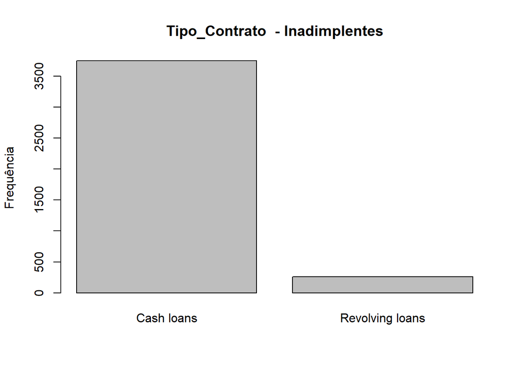

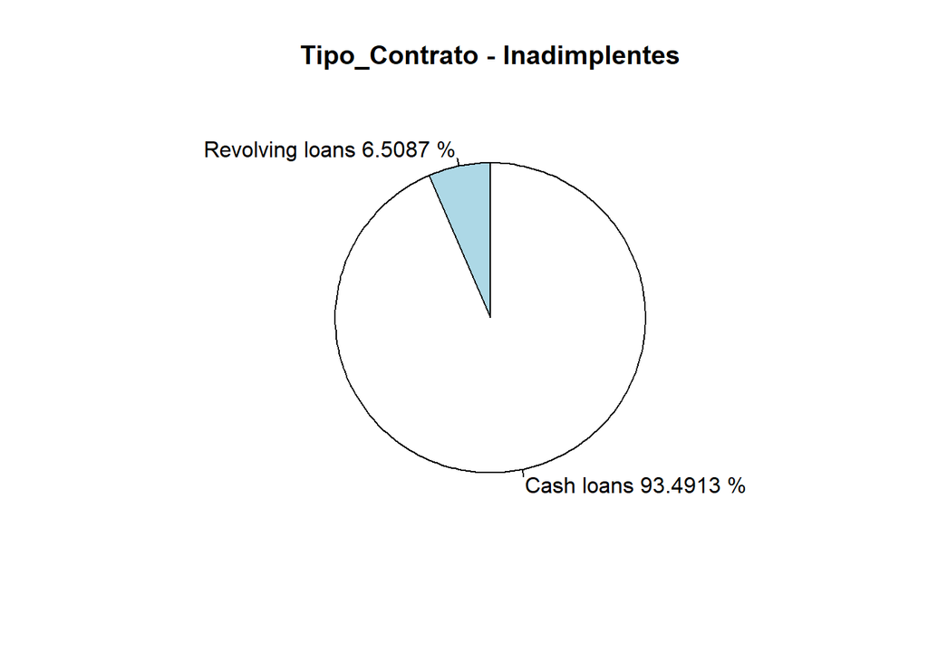

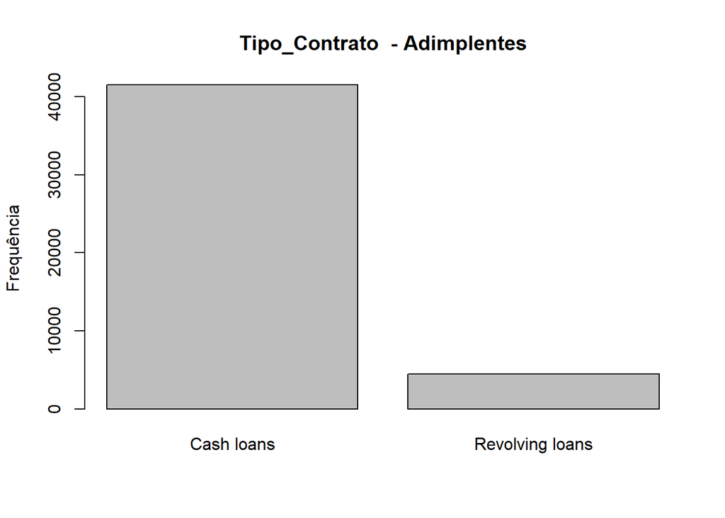

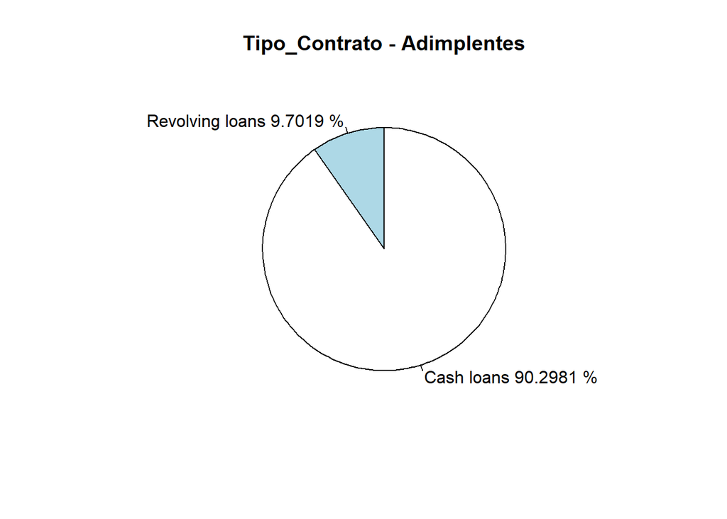

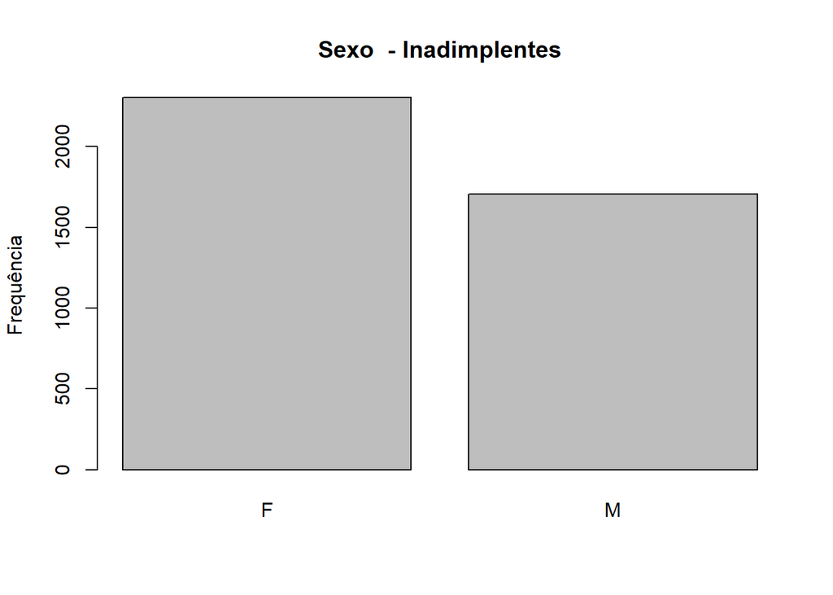

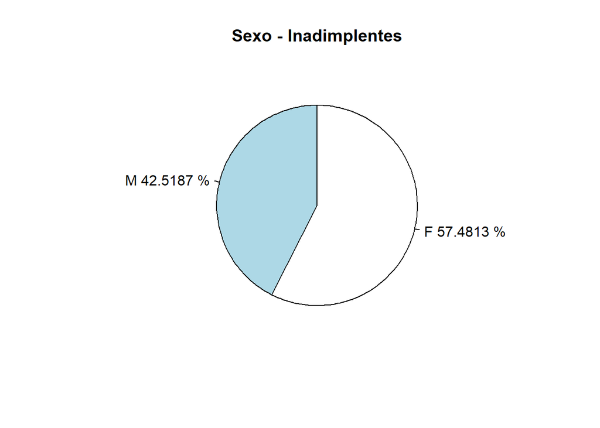

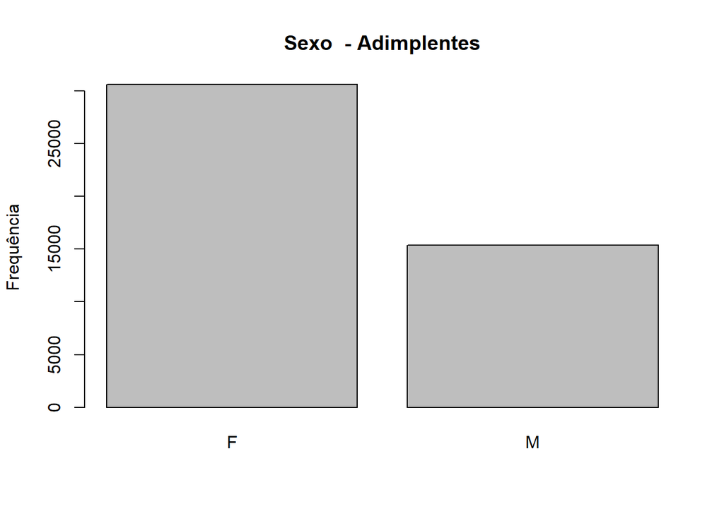

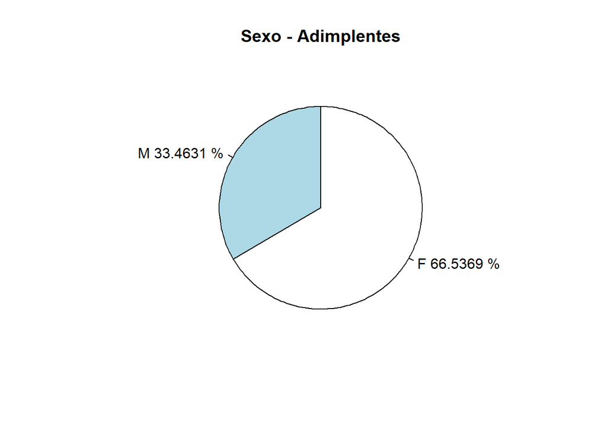

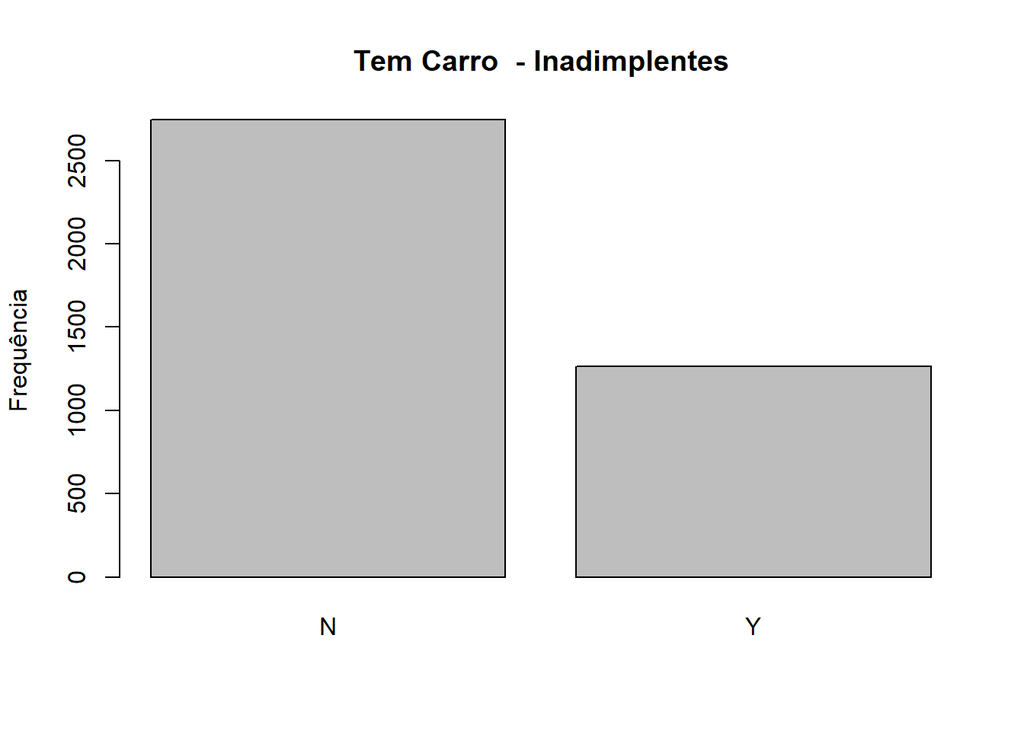

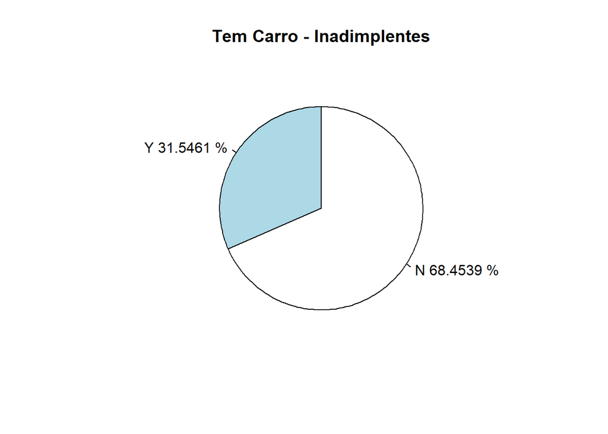

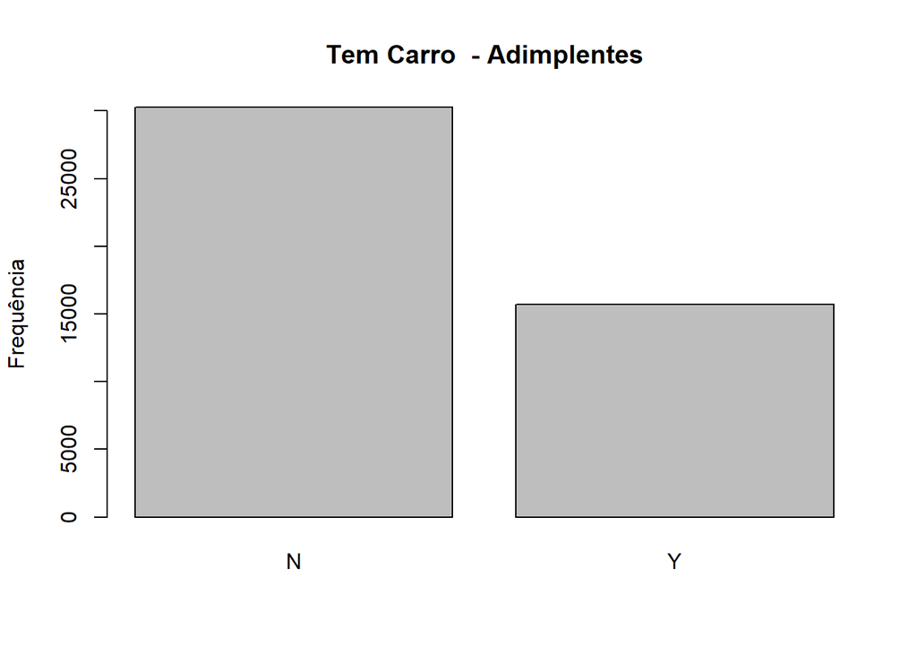

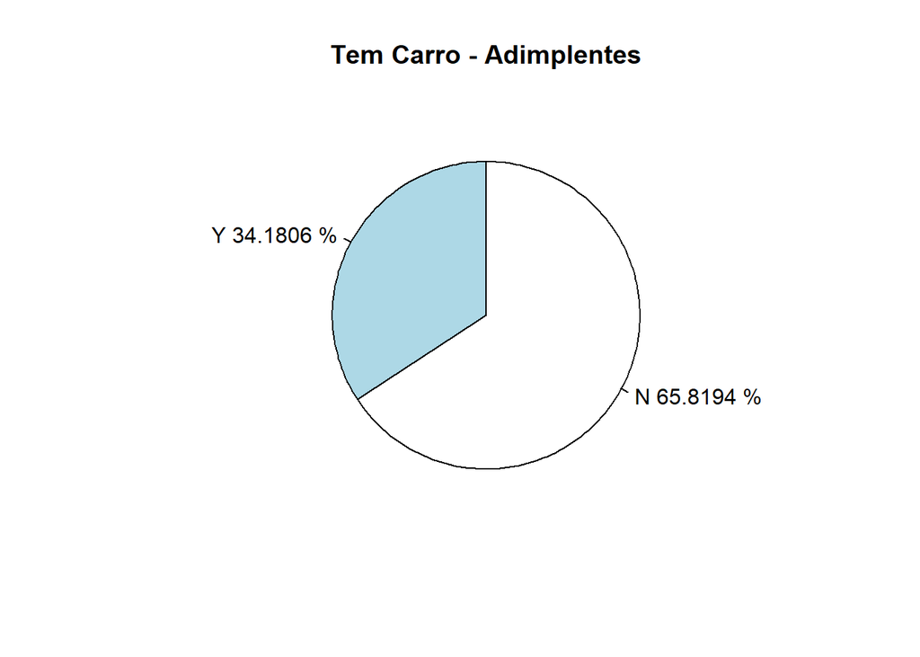

[24 more figures not shown]

#### **Conclusão sobre variáveis qualitativas:** Analisando graficamente através de histograma e gráfico de pizza, percebe-se a influência de algumas variáveis qualitativas, como segue:

- Tipo Residência
- Tipo de Contrato
- Sexo
- Carro
- Tipo Renda
- Estado Civil
- Dia da Semana que foi feita a proposta

### a-3) Análise Univariada de Variáveis Quantitativas

#### Sumário Inadimplentes

```
##      Renda        Volume_Financiamento Valor_Anual_Parcelas Populacao_Regiao   Membros_Familia      Filhos       Rating_Regiao_Moradia
##  Min.   : 31500   Min.   :  45000      Min.   : 3560        Min.   :0.001276   Min.   : 1.000   Min.   :0.0000   Min.   :1.00
##  1st Qu.:112500   1st Qu.: 278784      1st Qu.:17124        1st Qu.:0.009657   1st Qu.: 2.000   1st Qu.:0.0000   1st Qu.:2.00
##  Median :135000   Median : 494775      Median :25027        Median :0.018634   Median : 2.000   Median :0.0000   Median :2.00
##  Mean   :159076   Mean   : 548092      Mean   :26121        Mean   :0.019159   Mean   : 2.171   Mean   :0.4546   Mean   :2.16
##  3rd Qu.:202500   3rd Qu.: 720000      3rd Qu.:32328        3rd Qu.:0.025164   3rd Qu.: 3.000   3rd Qu.:1.0000   3rd Qu.:2.00
##  Max.   :900000   Max.   :3020760      Max.   :88943        Max.   :0.072508   Max.   :11.000   Max.   :9.0000   Max.   :3.00
```

#### Sumário Adimplentes

```
##      Renda         Volume_Financiamento Valor_Anual_Parcelas Populacao_Regiao   Membros_Familia      Filhos        Rating_Regiao_Moradia
##  Min.   :  26100   Min.   :  45000      Min.   :  2511       Min.   :0.000533   Min.   : 1.000   Min.   : 0.0000   Min.   :1.000
##  1st Qu.: 112500   1st Qu.: 270000      1st Qu.: 16434       1st Qu.:0.010006   1st Qu.: 2.000   1st Qu.: 0.0000   1st Qu.:2.000
##  Median : 144000   Median : 513531      Median : 24840       Median :0.018850   Median : 2.000   Median : 0.0000   Median :2.000
##  Mean   : 168193   Mean   : 599841      Mean   : 27095       Mean   :0.021009   Mean   : 2.146   Mean   : 0.4105   Mean   :2.042
##  3rd Qu.: 202500   3rd Qu.: 808650      3rd Qu.: 34587       3rd Qu.:0.028663   3rd Qu.: 3.000   3rd Qu.: 1.0000   3rd Qu.:2.000
##  Max.   :6750000   Max.   :4050000      Max.   :230162       Max.   :0.072508   Max.   :15.000   Max.   :14.0000   Max.   :3.000
```

#### Análise Bivariada

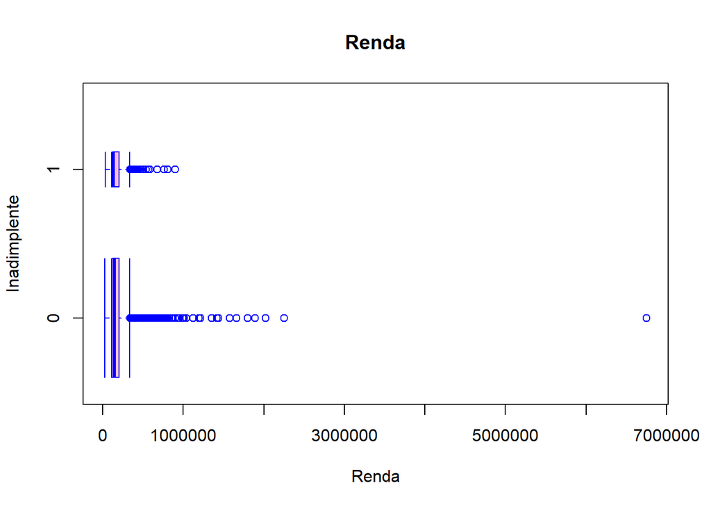

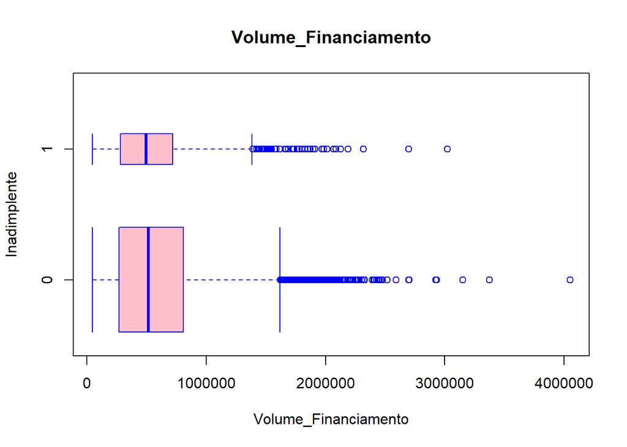

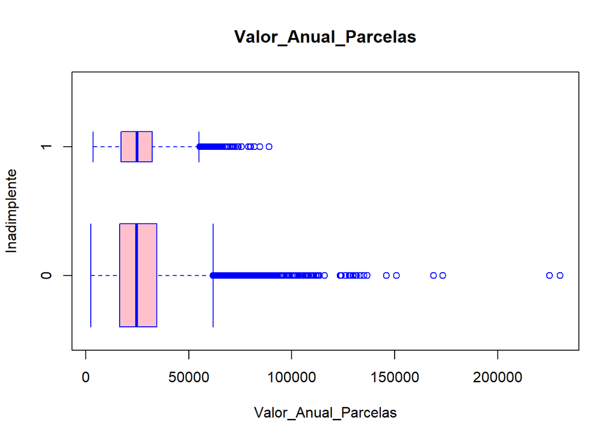

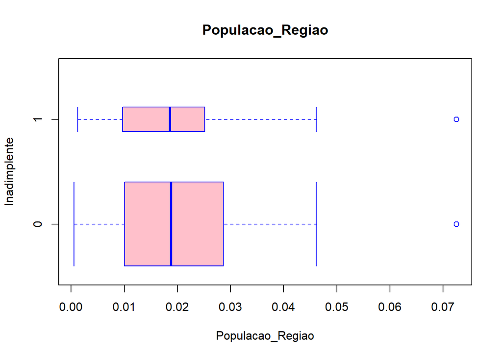

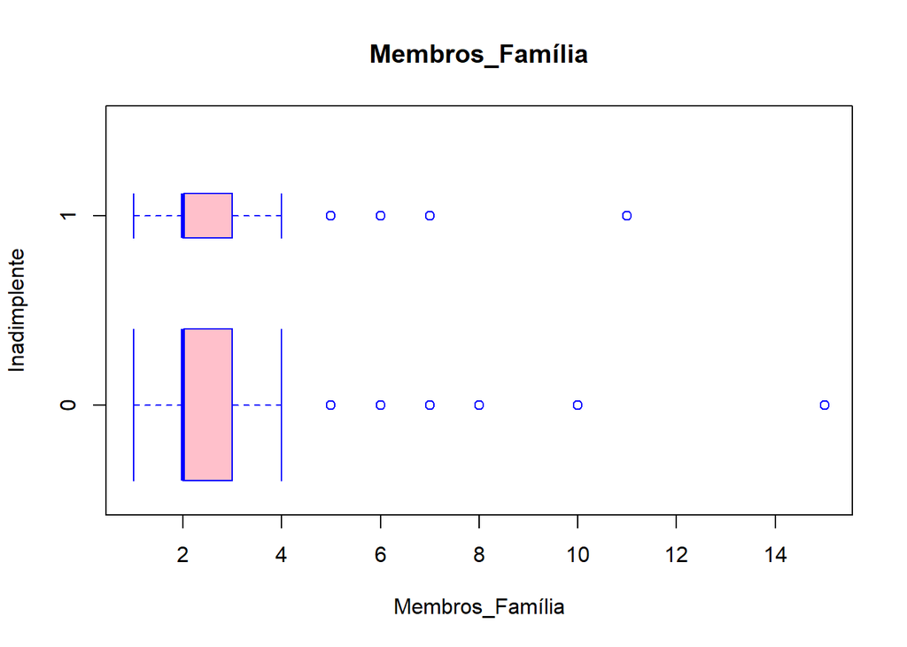

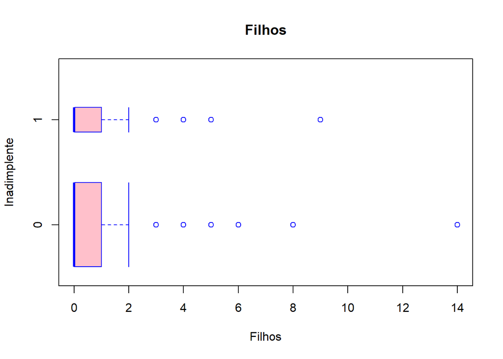

#### **Conclusão sobre variáveis quantitativas:** Não é possível gerar nenhum *insight* pois Os números entre inadimplentes e adimplentes são muito próximos.

## b) Calculo o IV das variáveis

```
##                     Variable                 IV
## 10                Tipo_Renda 0.0561705280644420
## 19     Rating_Regiao_Moradia 0.0543342623932869
## 7       Volume_Financiamento 0.0494242734472835
## 2                       Sexo 0.0349365626950444
## 13          Populacao_Regiao 0.0346030728192115
## 15         Tem_Tel_Comercial 0.0306723262165174
## 8       Valor_Anual_Parcelas 0.0302970100624882
## 11              Estado_Civil 0.0235382864826529
## 12           Tipo_Residencia 0.0171104857194400
## 1              Tipo_Contrato 0.0138560947839878
## 6                      Renda 0.0121756621553233
## 21             Hora_Proposta 0.0108784446687226
## 5                     Filhos 0.0036557626701332
## 18           Membros_Familia 0.0033271550400825
## 3                  Tem Carro 0.0031469375074350
## 20       Dia_Semana_Proposta 0.0030636087953762
## 9       Acompanhante_Cliente 0.0011376887491321
## 17                 Tem_Email 0.0005792328710591
## 22  Endereco_Contato_Correto 0.0004431437483524
## 23 Endereco_Trabalho_Correto 0.0002554916410174
## 4                   Tem_Casa 0.0000879565164137
## 16             Celular_Sinal 0.0000306192227808
## 14               Tem_Celular 0.0000000004727799
```

### c) Categorização das variáveis quantitativas com melhores resultados

#### c-1) Volume Financiamento

- IV Normal (Melhor Resultado): 0.0494
- IV com Quartil: 0.0285
- IV Otimizado: 0.0336

#### c-2) População da Região

```
##    Cutpoint CntRec CntGood CntBad CntCumRec CntCumGood CntCumBad PctRec GoodRate BadRate   Odds  LnOdds     WoE     IV
## 1 <= 0.0314  42594    3613  38981     42594       3613     38981 0.8519   0.0848  0.9152 0.0927 -2.3785  0.0611 0.0033
## 2 <= 0.0358   3840     240   3600     46434       3853     42581 0.0768   0.0625  0.9375 0.0667 -2.7081 -0.2684 0.0049
## 3  > 0.0358   3567     157   3410     50001       4010     45991 0.0713   0.0440  0.9560 0.0460 -3.0782 -0.6386 0.0223
## 4   Missing      0       0      0     50001       4010     45991 0.0000      NaN     NaN    NaN     NaN     NaN    NaN
## 5     Total  50001    4010  45991        NA         NA        NA 1.0000   0.0802  0.9198 0.0872 -2.4397  0.0000 0.0305
```

- IV Normal (Melhor Resultado): 0.0346
- IV com Quartil: 0.0185
- IV Otimizado: 0.0306

#### c-2) Valor Anual Parcelas

```
## [1] "data.frame"
```

```
##                          Variable                 IV
## 10                     Tipo_Renda 0.0561705280644420
## 19          Rating_Regiao_Moradia 0.0543342623932869
## 7            Volume_Financiamento 0.0494242734472835
## 2                            Sexo 0.0349365626950444
## 13               Populacao_Regiao 0.0346030728192115
## 29 Valor_Anual_Parcelas_Otimizado 0.0342570032746660
## 25 Volume_Financiamento_Otimizado 0.0335892730001008
## 15              Tem_Tel_Comercial 0.0306723262165174
## 27     Populacao_Regiao_Otimizado 0.0305555509823966
## 8            Valor_Anual_Parcelas 0.0302970100624882
## 24   Volume_Financiamento_Quartil 0.0284656649044127
## 11                   Estado_Civil 0.0235382864826529
## 26       Populacao_Regiao_Quartil 0.0185351207925987
## 28   Valor_Anual_Parcelas_Quartil 0.0175632521634725
## 12                Tipo_Residencia 0.0171104857194400
## 1                   Tipo_Contrato 0.0138560947839878
## 6                           Renda 0.0121756621553233
## 21                  Hora_Proposta 0.0108784446687226
## 5                          Filhos 0.0036557626701332
## 18                Membros_Familia 0.0033271550400825
## 3                       Tem Carro 0.0031469375074350
## 20            Dia_Semana_Proposta 0.0030636087953762
## 9            Acompanhante_Cliente 0.0011376887491321
## 17                      Tem_Email 0.0005792328710591
## 22       Endereco_Contato_Correto 0.0004431437483524
## 23      Endereco_Trabalho_Correto 0.0002554916410174
## 4                        Tem_Casa 0.0000879565164137
## 16                  Celular_Sinal 0.0000306192227808
## 14                    Tem_Celular 0.0000000004727799
```

- IV Normal: 0.0303
- IV com Quartil: 0.0176
- IV Otimizado (Melhor Resultado): 0.0343

### d) Divida a base em treino e teste e obtenha o modelo de regressão logística utilizando o método *Backward*, com 95% de confiança. Dado o número relativamente alto de variáveis, exclua as variáveis de IV fraquíssimo.

```
##
## Call:
## glm(formula = Inadimplente ~ Rating_Regiao_Moradia + Volume_Financiamento +
##     Sexo + Estado_Civil + Tipo_Contrato, family = binomial(link = "logit"),
##     data = treino)
##
## Deviance Residuals:
##     Min       1Q   Median       3Q      Max
## -0.6663  -0.4452  -0.3875  -0.3452   2.7385
##
## Coefficients:
##                                    Estimate     Std. Error z value             Pr(>|z|)
## (Intercept)                  -3.26067699692  0.09780796317 -33.338 < 0.0000000000000002 ***
## Rating_Regiao_Moradia         0.40376891578  0.03880985291  10.404 < 0.0000000000000002 ***
## Volume_Financiamento         -0.00000034550  0.00000005527  -6.251     0.00000000040874 ***
## SexoM                         0.37802297736  0.04063132985   9.304 < 0.0000000000000002 ***
## Estado_CivilSingle            0.29672301706  0.04463951539   6.647     0.00000000002989 ***
## Estado_CivilWidow/Separated  -0.01206440169  0.06704437842  -0.180                0.857
## Tipo_ContratoRevolving loans -0.55793276591  0.08132593335  -6.860     0.00000000000686 ***
## ---
## Signif. codes:  0 '***' 0.001 '**' 0.01 '*' 0.05 '.' 0.1 ' ' 1
##
## (Dispersion parameter for binomial family taken to be 1)
##
##     Null deviance: 19611  on 34999  degrees of freedom
## Residual deviance: 19270  on 34993  degrees of freedom
## AIC: 19284
##
## Number of Fisher Scoring iterations: 5
```

### e) Verifique se há multicolinearidade.

VIF

| variable | gvif | df | gvif^(1/(2*df)) |
| --- | --- | --- | --- |
| Rating_Regiao_Moradia | 1.006288 | 1 | 1.003139 |
| Volume_Financiamento | 1.062039 | 1 | 1.030552 |
| Sexo | 1.025910 | 1 | 1.012872 |
| Estado_Civil | 1.047445 | 2 | 1.011656 |
| Tipo_Contrato | 1.035770 | 1 | 1.017728 |

### f) Calcule o K-S e o AUC para o modelo na base de treino e teste. Alguma disparidade entre os resultados desses indicadores? Como você avalia a qualidade desse modelo?

#### f-1) Base Treino

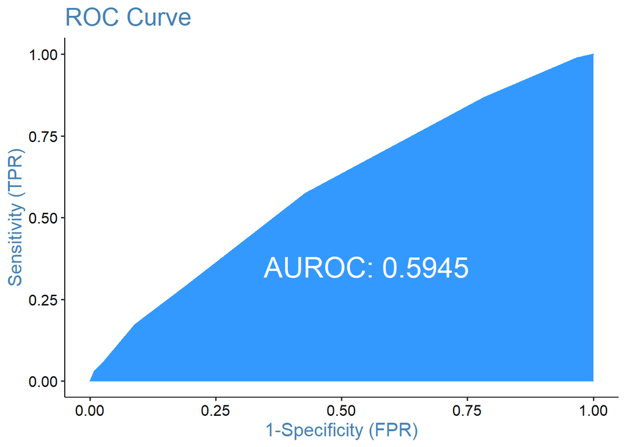

- K-S Treino: 0.1469

### f-2) Base Teste

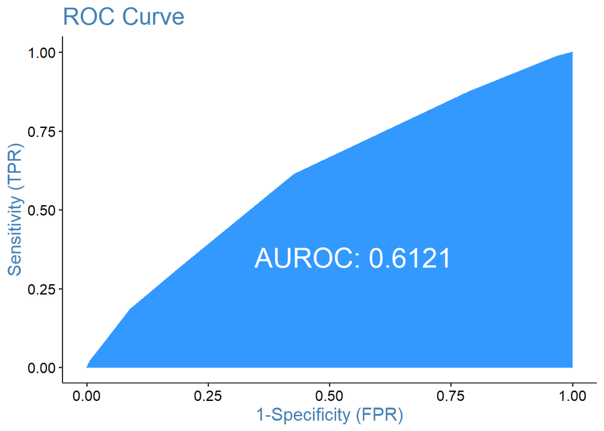

- K-S Teste: 0.1935

### g) Mostre a tabela de distribuição do score, por decis. Qual o % de inadimplência por faixa? O score ordena o risco dos clientes de forma adequada?

|  | treino$Inadimplente 0 | treino$Inadimplente 1 |
| --- | --- | --- |
| treino$probb_faixas |  |  |
| [0.0149,0.0491) | 96 | 4 |
| [0.0491,0.0593) | 94.4 | 5.6 |
| [0.0593,0.0646) | 93 | 7 |
| [0.0646,0.0698) | 92.4 | 7.6 |
| [0.0698,0.0745) | 93.2 | 6.8 |
| [0.0745,0.0842) | 93.6 | 6.4 |
| [0.0842,0.093) | 91.1 | 8.9 |
| [0.093,0.0999) | 89.4 | 10.6 |
| [0.0999,0.118) | 90.8 | 9.2 |
| [0.118,0.199] | 85.7 | 14.3 |
| #Total cases | 32180 | 2820 |